# Questionnaire Data Analysis

## 2.3 Calculating Outcome Variables (Pre-test)

Next, the outcome variables based on the given dataset are computed.

### 2.3.1 Calculating Questionnaire Outcome Variables (Except MCTQ)

All outcome variables (except MCTQ) are calculated by taking the total score.

```r
# Calculating the total scores for pretest data
df_pretest_Q <- data.frame(ID_reg = dataQ$registration_id,
                         ID_user = dataQ$user_id,
                 ISI_total = rowSums(dataQ[, 81:87]),
                 PHQ_total = rowSums(dataQ[, 46:54]),
                 GAD_total = rowSums(dataQ[, 56:62]),
                 WSAS_total = rowSums(dataQ[, 64:68]),
                 MHQol_total = rowSums(dataQ[, 69:76]))


df_pretest_Q
```

```
##    ID_reg ID_user ISI_total PHQ_total GAD_total WSAS_total MHQol_total
## 1    5388    4258        13         4         2          6          20
## 2    5413      NA        20        14        13         24          22
## 3    5438    4293        22        15        15         38          24
## 4    5447    4300        11         6         0         10          19
## 5    5449      NA        15        NA        NA         NA          NA
## 6    5453    4304        16        11        10         10          23
## 7    5507    4343        13         7         4         13          20
## 8    5525    4357        14        11         7         14          18
## 9    5577      NA        21        13        12         21          21
## 10   5578      NA        18        NA        NA         NA          NA
## 11   5594    4408        14        11         7         17          23
## 12   5601      NA        15         9         7         20          24
## 13   5620    4429        22         8        11         23          21
## 14   5624      NA        11        NA        NA         NA          NA
## 15   5637    4440        16        15        11         29          21
## 16   5644      NA        12         7         8          6          19
## 17   5647    4447        20        12        10         15          16
## 18   5649      NA        17         7         9         13          20
## 19   5678    4474        17        17        18         11          20
## 20   5727    4515        21        11         5         21          18
## 21   5739    4528        12        16        10         22          21
## 22   5745      NA        10        NA        NA         NA          NA
## 23   5757    4542        20         7         0         12          23
## 24   5763    4545        18        13        14         19          18
## 25   5773    4552        15        10         7         29          25
```

### 2.3.2 Calculating MCTQ variables

```r
##### MTCQ BASIC VARIABLES #####

# Changing the MTCQ variables to same timeformat
library(hms)
dataQ$mctq_werk_daadwerkelijk_slapen_om...11 <- strptime(
  dataQ$mctq_werk_daadwerkelijk_slapen_om...11, format = "%Y-%m-%d %H:%M:%S")

dataQ$mctq_werk_daadwerkelijk_slapen_om...9 <- strptime(
  dataQ$mctq_werk_daadwerkelijk_slapen_om...9, format = "%Y-%m-%d %H:%M:%S")

dataQ$mctq_vrij_daadwerkelijk_slapen_om...18 <- strptime(
  dataQ$mctq_vrij_daadwerkelijk_slapen_om...18, format = "%Y-%m-%d %H:%M:%S")

dataQ$mctq_vrij_daadwerkelijk_slapen_om...16 <- strptime(
  dataQ$mctq_vrij_daadwerkelijk_slapen_om...16, format = "%Y-%m-%d %H:%M:%S")


# Calculating the first MTCQ variables (most results are in hh:mm:ss format)
library(lubridate)
df_MCTQ <- data.frame(WD = dataQ$mctq_studie_werk_dagenperweek,
                      SEw = dataQ$mctq_werk_daadwerkelijk_slapen_om...11,
                      FD = 7 - dataQ$mctq_studie_werk_dagenperweek,
                      SOw = dataQ$mctq_werk_daadwerkelijk_slapen_om...9
                      + minutes(dataQ$mctq_werk_minuten_in_slaap),
                      SOf = dataQ$mctq_vrij_daadwerkelijk_slapen_om...16
                      + minutes(dataQ$mctq_vrij_minuten_in_slaap),
                      SEf = dataQ$mctq_vrij_daadwerkelijk_slapen_om...18)


# Increase time in SEw and SEf by 1 day
df_MCTQ$SEw <- df_MCTQ$SEw + days(1)
df_MCTQ$SEf <- df_MCTQ$SEf + days(1)

# If time in SOw is after midnight (between 12AM and 17PM),
# we increase the day by 1
date_condition =  strptime("1899-12-31 17:00:00", format = "%Y-%m-%d %H:%M:%S")
for (i in 1:nrow(df_MCTQ)){

  if(is.na(df_MCTQ$SOw[i])) next # Skip missing values

  if (df_MCTQ$SOw[i] < date_condition){
    df_MCTQ$SOw[i] = df_MCTQ$SOw[i] + days(1)
  }
}

# If time in SOf is after midnight (between 12AM and 17PM),
# we increase the day by 1
for (i in 1:nrow(df_MCTQ)){

  if(is.na(df_MCTQ$SOf[i])) next # Skip missing values

  if (df_MCTQ$SOf[i] < date_condition){
    df_MCTQ$SOf[i] = df_MCTQ$SOf[i] + days(1)
  }
}

# Calculating rest of MTCQ basic variables
df_MCTQ$SDw <- as_hms(df_MCTQ$SEw - df_MCTQ$SOw)
df_MCTQ$SDf <- as_hms(df_MCTQ$SEf - df_MCTQ$SOf)


##### MTCQ COMPUTED VARIABLES #####

# 1. Average weekly sleep duration: (SDw x WD + SDf x FD )/7
df_pretest_Q$mctq_SDweek <- as_hms((df_MCTQ$SDw * df_MCTQ$WD
                                    + df_MCTQ$SDf * df_MCTQ$FD) / 7)

# 2. Weekly sleep loss:
# If SDweek > SDw: (SDweek - SDw) x WD;
# If SDweek <= SDw: (SDweek - SDf) x FD

df_pretest_Q$mctq_SLossWeek  <- ifelse(df_pretest_Q$mctq_SDweek > df_MCTQ$SDw,
                                       (df_pretest_Q$mctq_SDweek - df_MCTQ$SDw)
                                       * df_MCTQ$WD,
                                       (df_pretest_Q$mctq_SDweek - df_MCTQ$SDf)
                                       * df_MCTQ$FD)
df_pretest_Q$mctq_SLossWeek <- as_hms(df_pretest_Q$mctq_SLossWeek)

# 3. Mid sleep on weekdays: SOw + SDw/2 = (SPrepw + SLatw) + SDw/2
df_pretest_Q$mctq_MSW <- as_hms(df_MCTQ$SOw + df_MCTQ$SDw /2)

# 4. Mid sleep on weekends: SOf + SDf/2 = (SPrepf + SLatf) +  SDf/2
df_pretest_Q$mctq_MSF <- as_hms(df_MCTQ$SOf + df_MCTQ$SDf/2)

# 5. Absolute Social jetlag
df_pretest_Q$mctq_SJL <- as_hms(abs(df_pretest_Q$mctq_MSF
                                    - df_pretest_Q$mctq_MSW))
```

## 2.4 Examining Outcome Variables

Examining the Densities

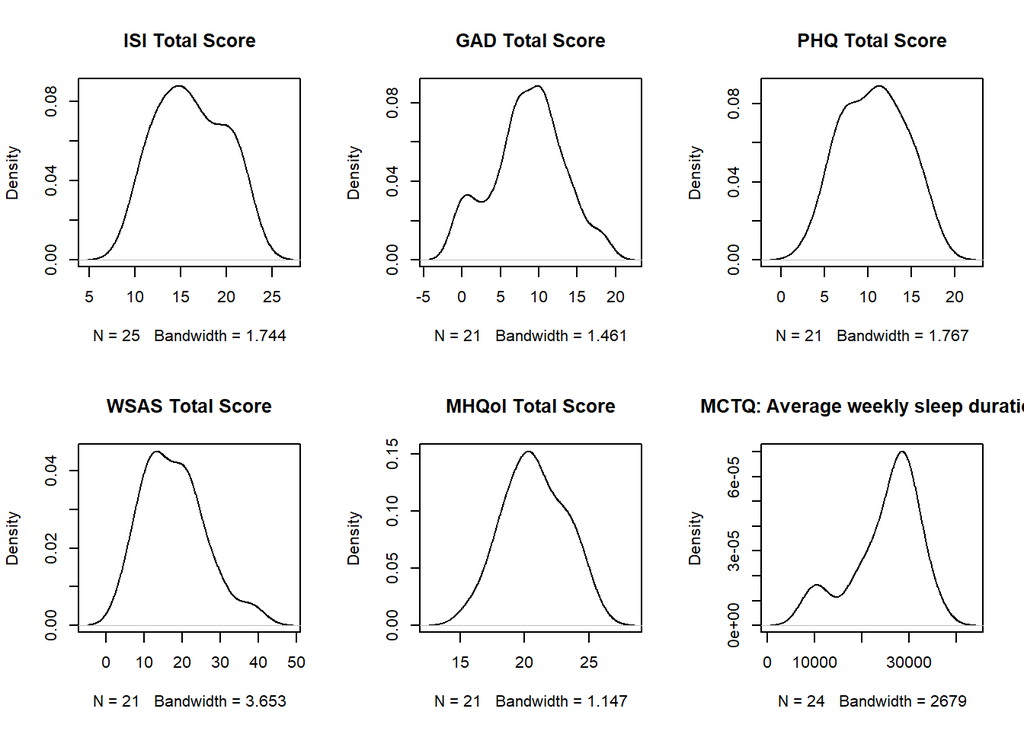

```r
# Examining the densities of each outcome variable
par(mfrow=c(2,3))

plot(density(df_pretest_Q$ISI_total), main = "ISI Total Score")
plot(density(df_pretest_Q$GAD_total, na.rm = T), main = "GAD Total Score")
plot(density(df_pretest_Q$PHQ_total, na.rm = T),  main = "PHQ Total Score")
plot(density(df_pretest_Q$WSAS_total, na.rm = T),  main = "WSAS Total Score")
plot(density(df_pretest_Q$MHQol_total, na.rm = T),  main = "MHQol Total Score")

plot(density(as.numeric(df_pretest_Q$mctq_SDweek), na.rm = T),
     main = "MCTQ: Average weekly sleep duration")
```

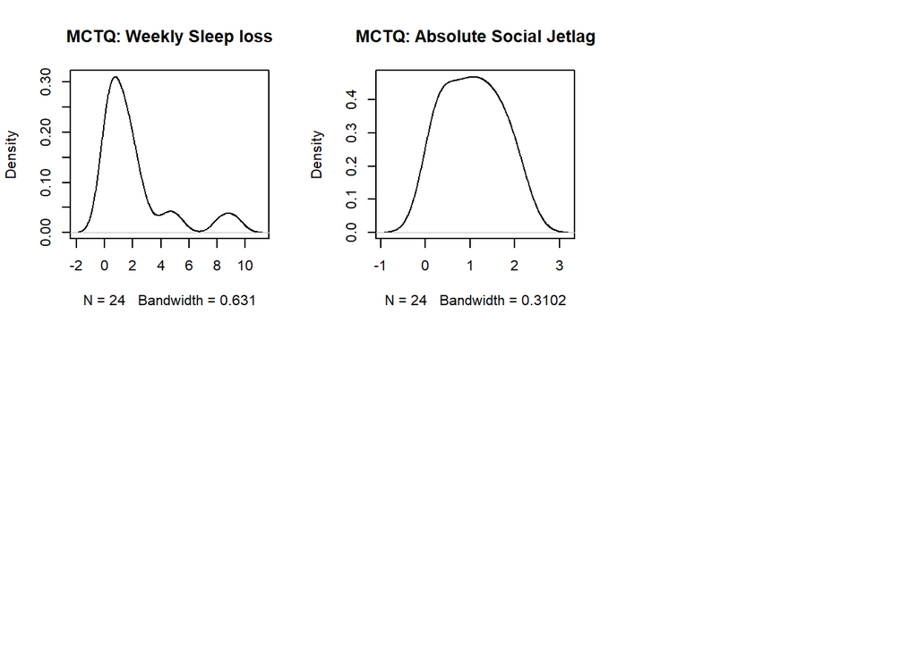

```r
plot(density(as.numeric(df_pretest_Q$mctq_SLossWeek) / 60 / 60,
             na.rm = T),
     main = "MCTQ: Weekly Sleep loss")
plot(density(as.numeric(df_pretest_Q$mctq_SJL) / 60 / 60, na.rm = T),
     main = "MCTQ: Absolute Social Jetlag")
```

We can see from the density plots that most variables are not normally distributed and we have to take this into account in the simulation.

# 3.Simulating Data

## 3.1 Post-treatment Simulation

First, the outcome variables for the post-treatment results (n = 3) are calculated based on the received data. The code is the same as used to calculate the pre-test variables.

```r
#####  TOTAL SCORES #####

df_posttest_Q <- data.frame(ID_reg = dataQ_post$registration_id,
                         ID_user = dataQ_post$user_id,
                 ISI_total = rowSums(dataQ_post[, 6:12]),
                 PHQ_total = rowSums(dataQ_post[, 53:61]),
                 GAD_total = rowSums(dataQ_post[, 63:69]),
                 WSAS_total = rowSums(dataQ_post[, 71:75]),
                 MHQol_total = rowSums(dataQ_post[, 76:83]))

##### MTCQ BASIC VARIABLES #####

# Changing the MTCQ variables to same timeformat
library(hms)
dataQ_post$Post_mctq_werk_daadwerkelijk_slapen_om...16 <- strptime(
  dataQ_post$Post_mctq_werk_daadwerkelijk_slapen_om...16,
  format = "%Y-%m-%d %H:%M:%S")

dataQ_post$Post_mctq_werk_daadwerkelijk_slapen_om...18 <- strptime(
  dataQ_post$Post_mctq_werk_daadwerkelijk_slapen_om...18,
  format = "%Y-%m-%d %H:%M:%S")

dataQ_post$Post_mctq_vrij_daadwerkelijk_slapen_om...23 <- strptime(
  dataQ_post$Post_mctq_vrij_daadwerkelijk_slapen_om...23,
  format = "%Y-%m-%d %H:%M:%S")

dataQ_post$Post_mctq_vrij_daadwerkelijk_slapen_om...25 <- strptime(
  dataQ_post$Post_mctq_vrij_daadwerkelijk_slapen_om...25,
  format = "%Y-%m-%d %H:%M:%S")


# Calculating the first MTCQ variables (most results are in hh:mm:ss format)
library(lubridate)

df_MCTQ_post <- data.frame(WD = dataQ_post$Post_mctq_studie_werk_dagenperweek,
                      SEw =
                        dataQ_post$Post_mctq_werk_daadwerkelijk_slapen_om...18,
                      FD = 7 - dataQ_post$Post_mctq_studie_werk_dagenperweek,

                      SOw =
                        dataQ_post$Post_mctq_werk_daadwerkelijk_slapen_om...16
                      + minutes(dataQ_post$Post_mctq_werk_minuten_in_slaap),
                      SOf =
                        dataQ_post$Post_mctq_vrij_daadwerkelijk_slapen_om...23
                      + minutes(dataQ_post$Post_mctq_vrij_minuten_in_slaap),
                      SEf =
                        dataQ_post$Post_mctq_vrij_daadwerkelijk_slapen_om...25)
# Increase time in SEw and SEf by 1 day
df_MCTQ_post$SEw <- df_MCTQ_post$SEw + days(1)
df_MCTQ_post$SEf <- df_MCTQ_post$SEf + days(1)

# If time in SOw is after midnight (between 12AM and 17PM),
# we increase the day by 1
date_condition =  strptime("1899-12-31 17:00:00", format = "%Y-%m-%d %H:%M:%S")
for (i in 1:nrow(df_MCTQ_post)){

  if(is.na(df_MCTQ_post$SOw[i])) next # Skip missing values

  if (df_MCTQ_post$SOw[i] < date_condition){
    df_MCTQ_post$SOw[i] = df_MCTQ_post$SOw[i] + days(1)
  }
}

# If time in SOf is after midnight (between 12AM and 17PM),
# we increase the day by 1
for (i in 1:nrow(df_MCTQ_post)){

  if(is.na(df_MCTQ_post$SOf[i])) next # Skip missing values

  if (df_MCTQ_post$SOf[i] < date_condition){
    df_MCTQ_post$SOf[i] = df_MCTQ_post$SOf[i] + days(1)
  }
}

# Calculating rest of MTCQ basic variables
df_MCTQ_post$SDw <- as_hms(df_MCTQ_post$SEw - df_MCTQ_post$SOw)
df_MCTQ_post$SDf <- as_hms(df_MCTQ_post$SEf - df_MCTQ_post$SOf)


##### MTCQ COMPUTED VARIABLES #####

# 1. Average weekly sleep duration: (SDw x WD + SDf x FD )/7
df_posttest_Q$mctq_SDweek <- as_hms((df_MCTQ_post$SDw * df_MCTQ_post$WD
                                     + df_MCTQ_post$SDf * df_MCTQ_post$FD) / 7)

# 2. Weekly sleep loss:
# If SDweek > SDw: (SDweek - SDw) x WD;
# If SDweek <= SDw: (SDweek - SDf) x FD

df_posttest_Q$mctq_SLossWeek  <- ifelse(
  df_posttest_Q$mctq_SDweek > df_MCTQ_post$SDw,
  (df_posttest_Q$mctq_SDweek - df_MCTQ_post$SDw)
  * df_MCTQ_post$WD,
  (df_posttest_Q$mctq_SDweek - df_MCTQ_post$SDf) * df_MCTQ_post$FD)
df_posttest_Q$mctq_SLossWeek <- as_hms(df_posttest_Q$mctq_SLossWeek)

# 3. Mid sleep on weekdays: SOw + SDw/2 = (SPrepw + SLatw) + SDw/2
df_posttest_Q$mctq_MSW <- as_hms(df_MCTQ_post$SOw + df_MCTQ_post$SDw /2)

# 4. Mid sleep on weekends: SOf + SDf/2 = (SPrepf + SLatf) +  SDf/2
df_posttest_Q$mctq_MSF <- as_hms(df_MCTQ_post$SOf + df_MCTQ_post$SDf/2)

# 5. Absolute Social jetlag
df_posttest_Q$mctq_SJL <- as_hms(abs(df_posttest_Q$mctq_MSF
                                     - df_posttest_Q$mctq_MSW))
```

Next, the mean and SD of each outcome variable is calculated to get the fixed parameters for the simulation.

```r
# Calculating means and SD for the post-results
# NOTE: The MCTQ variables are reported in seconds
stat_post <- data.frame(mean = c(mean(df_posttest_Q$ISI_total),
                                      mean(df_posttest_Q$PHQ_total),
                                      mean(df_posttest_Q$GAD_total),
                                      mean(df_posttest_Q$WSAS_total),
                                      mean(df_posttest_Q$MHQol_total),
                                      mean(df_posttest_Q$mctq_SDweek,
                                           na.rm = T),
                                      mean(df_posttest_Q$mctq_SLossWeek,
                                           na.rm = T),
                                      mean(df_posttest_Q$mctq_MSW,
                                           na.rm = T),
                                      mean(df_posttest_Q$mctq_MSF,
                                           na.rm = T),
                                      mean(df_posttest_Q$mctq_SJL,
                                           na.rm = T)),

                             sd = c(sd(df_posttest_Q$ISI_total),
                                      sd(df_posttest_Q$PHQ_total),
                                      sd(df_posttest_Q$GAD_total),
                                      sd(df_posttest_Q$WSAS_total),
                                      sd(df_posttest_Q$MHQol_total),
                                      sd(df_posttest_Q$mctq_SDweek,
                                         na.rm = T),
                                      sd(df_posttest_Q$mctq_SLossWeek,
                                         na.rm = T),
                                      sd(df_posttest_Q$mctq_MSW,
                                         na.rm = T),
                                      sd(df_posttest_Q$mctq_MSF,
                                         na.rm = T),
                                      sd(df_posttest_Q$mctq_SJL,
                                         na.rm = T)))

stat_pre <- data.frame(mean = c(mean(df_pretest_Q$ISI_total),
                                      mean(df_pretest_Q$PHQ_total,
                                           na.rm = T),
                                      mean(df_pretest_Q$GAD_total,
                                           na.rm = T),
                                      mean(df_pretest_Q$WSAS_total,
                                           na.rm = T),
                                      mean(df_pretest_Q$MHQol_total,
                                           na.rm = T),
                                      mean(df_pretest_Q$mctq_SDweek,
                                           na.rm = T),
                                      mean(df_pretest_Q$mctq_SLossWeek,
                                           na.rm = T),
                                      mean(df_pretest_Q$mctq_MSW,
                                           na.rm = T),
                                      mean(df_pretest_Q$mctq_MSF,
                                           na.rm = T),
                                      mean(df_pretest_Q$mctq_SJL,
                                           na.rm = T)),

                             sd = c(sd(df_pretest_Q$ISI_total,
                                       na.rm = T),
                                      sd(df_pretest_Q$PHQ_total
                                         ,na.rm = T),
                                      sd(df_pretest_Q$GAD_total,
                                         na.rm = T),
                                      sd(df_pretest_Q$WSAS_total,
                                         na.rm = T),
                                      sd(df_pretest_Q$MHQol_total,
                                         na.rm = T),
                                      sd(df_pretest_Q$mctq_SDweek,
                                         na.rm = T),
                                      sd(df_pretest_Q$mctq_SLossWeek,
                                         na.rm = T),
                                      sd(df_pretest_Q$mctq_MSW,
                                         na.rm = T),
                                      sd(df_pretest_Q$mctq_MSF,
                                         na.rm = T),
                                      sd(df_pretest_Q$mctq_SJL, na.rm = T)))


rownames(stat_post) <- c("ISI", "PHQ", "GAD", "WSAS", "MHQol", "SDWeek",
                         "SLossWeek", "MSW", "MSF", "SJL")

rownames(stat_pre) <- c("ISI", "PHQ", "GAD", "WSAS", "MHQol", "SDWeek",
                         "SLossWeek", "MSW", "MSF", "SJL")
```

Finally, we simulate data for the missing participants. The shape of each variable (“moments”) is studied by using the package PearsonDS and then we simulate data from a similar distribution (using the moments we found earlier and using the parameters determined by earlier studies) by using function rPearson.

```r
set.seed(12345)
library(PearsonDS)
########################################
#### DETERMING THE SHAPE / MOMENTS ####
######################################

# User ID's we want for simulated post-treatment
ID_reg <- df_pretest_Q$ID_reg
ID_reg <- ID_reg[c(2:3, 5:6, 8:25)] # Removing ID's that have post-treatment results


### The moments and parameters for simulation ###
ISI_param <- pearsonFitML(df_pretest_Q$ISI_total)
ISI_moments1 <- empMoments(df_pretest_Q$ISI_total)
ISI_moments <- c(mean = 9.57,
                 variance = ( 0.79 * sqrt(length(df_pretest_Q$ISI_total)))^2,
                 skewness = ISI_moments1[3],
                 kurtosis = ISI_moments1[4])

sim_data <- df_pretest_Q[!is.na(df_pretest_Q$PHQ_total), ] # Remove obs. with NA
PHQ_param <- pearsonFitML(sim_data$PHQ_total)
PHQ_moments1 <- empMoments(sim_data$PHQ_total)
PHQ_moments <- c(mean = 4.41,
                 variance = (0.55 * sqrt(length(sim_data$PHQ_total)))^2,
                 skewness = PHQ_moments1[3],
                 kurtosis = PHQ_moments1[4])

sim_data <- df_pretest_Q[!is.na(df_pretest_Q$GAD_total), ]
GAD_param <- pearsonFitML(sim_data$GAD_total)
GAD_moments1 <- empMoments(sim_data$GAD_total)
GAD_moments <- c(mean = 5.1,
                 variance = 4.7^2,
                 skewness = GAD_moments1[3],
                 kurtosis = GAD_moments1[4])

sim_data <- df_pretest_Q[!is.na(df_pretest_Q$WSAS_total), ]
WSAS_param <- pearsonFitML(sim_data$WSAS_total)
WSAS_moments1 <- empMoments(sim_data$WSAS_total)
WSAS_moments <- c(mean = 7.5,
                 variance = 8.6^2,
                 skewness = WSAS_moments1[3],
                 kurtosis = WSAS_moments1[4])

sim_data <- df_pretest_Q[!is.na(df_pretest_Q$MHQol_total), ]
MHQol_param <- pearsonFitML(sim_data$MHQol_total)
MHQol_moments1 <- empMoments(sim_data$MHQol_total)
MHQol_moments <- c(mean = stat_post[5, 1],
                 variance = var(sim_data$MHQol_total),
                 skewness = MHQol_moments1[3],
                 kurtosis = MHQol_moments1[4])

sim_data <- df_pretest_Q[!is.na(df_pretest_Q$mctq_SDweek), ]
mctq_SDweek_param <- pearsonFitML(as.numeric(sim_data$mctq_SDweek))
mctq_SDweek_moments1 <- empMoments(as.numeric(sim_data$mctq_SDweek))
mctq_SDweek_moments <- c(mean =  stat_post[6, 1],
                 variance = var(sim_data$mctq_SDweek),
                 skewness = mctq_SDweek_moments1[3],
                 kurtosis = mctq_SDweek_moments1[4])

sim_data <- df_pretest_Q[!is.na(df_pretest_Q$mctq_SLossWeek), ]
mctq_SLossWeek_param <- pearsonFitML(as.numeric(sim_data$mctq_SLossWeek))
mctq_SLossWeek_moments1 <- empMoments(as.numeric(sim_data$mctq_SLossWeek))
mctq_SLossWeek_moments <- c(mean =  stat_post[7, 1],
                 variance = var(sim_data$mctq_SLossWeek),
                 skewness = mctq_SLossWeek_moments1[3],
                 kurtosis = mctq_SLossWeek_moments1[4])

sim_data <- df_pretest_Q[!is.na(df_pretest_Q$mctq_MSW), ]
mctq_MSW_param <- pearsonFitML(as.numeric(sim_data$mctq_MSW))
mctq_MSW_moments1 <- empMoments(as.numeric(sim_data$mctq_MSW))
mctq_MSW_moments <- c(mean = stat_post[8, 1],
                 variance = var(sim_data$mctq_MSW),
                 skewness = mctq_MSW_moments1[3],
                 kurtosis = mctq_MSW_moments1[4])

sim_data <- df_pretest_Q[!is.na(df_pretest_Q$mctq_MSF), ]
mctq_MSF_param <- pearsonFitML(as.numeric(sim_data$mctq_MSF))
mctq_MSF_moments1 <- empMoments(as.numeric(sim_data$mctq_MSF))
mctq_MSF_moments <- c(mean =  stat_post[9, 1],
                 variance = var(sim_data$mctq_MSF),
                 skewness = mctq_MSF_moments1[3],
                 kurtosis = mctq_MSF_moments1[4])



#####################
#### SIMULATION ####
###################

# All the outcome variable for post-results are simulated by using the
# shape/moments observed in the data by the giving the parameters
# (mean and variance)

df_postsim_Q <- data.frame(

  ID_reg = ID_reg,

  ISI_total = round(rpearson(n = length(df_pretest_Q$ISI_total) - 3,
                             moments = ISI_moments,
                             params = ISI_param)),

  PHQ_total = round(rpearson(n = length(df_pretest_Q$PHQ_total) - 3,
                             moments = PHQ_moments,
                             params = PHQ_param)),

  GAD_total = round(rpearson(n = length(df_pretest_Q$GAD_total) - 3,
                             moments = GAD_moments,
                             params = GAD_param)),

  WSAS_total = round(rpearson(n = length(df_pretest_Q$WSAS_total) - 3,
                             moments = WSAS_moments,
                             params = WSAS_param)),

  MHQol_total = round(rpearson(n = length(df_pretest_Q$MHQol_total) - 3,
                             moments = MHQol_moments,
                             params = MHQol_param)),

  mctq_SDweek = round(rpearson(n = length(df_pretest_Q$mctq_SDweek) - 3,
                             moments = mctq_SDweek_moments,
                             params = mctq_SDWeek_param)),

  mctq_SLossWeek = round(rpearson(n = length(df_pretest_Q$mctq_SLossWeek) - 3,
                             moments = mctq_SLossWeek_moments,
                             params = mctq_SLossWeek_param)),

  mctq_MSW = round(rpearson(n = length(df_pretest_Q$mctq_MSW) - 3,
                             moments = mctq_MSW_moments,
                             params = mctq_MSW_param)),

  mctq_MSF = round(rpearson(n = length(df_pretest_Q$mctq_MSF) - 3,
                             moments = mctq_MSF_moments,
                             params = mctq_MSF_param))
)
# Calculating absolute social jetlag
df_postsim_Q$mctq_SJL <- abs(df_postsim_Q$mctq_MSF - df_postsim_Q$mctq_MSW)

# Changing scores that are below 0 to 0
df_postsim_Q[df_postsim_Q < 0] <- 0

# Combining the three post-results and the simulated results
df_Q_post_final <- rbind(df_posttest_Q[, c(1, 3:12)], df_postsim_Q)
```

The explanation for the choices for all the parameters (mean and variance) can be found in the report in Appendix E.

The table “df_Q_post_final” includes all the post-treatment data: the data of the three original participants and simulated data.

```r
# Changing the total scores of simulated of participants,
# that are missing pre-test values, to NA
df_Q_post_final[6, c(3:11)] <- NA
df_Q_post_final[10, c(3:6)] <- NA
df_Q_post_final[14, c(3:6)] <- NA
df_Q_post_final[22, c(3:6)] <- NA
```